# Practical 1 - Linear (Mixed) Models

In this practical we are going to fit linear (mixed) models in `inlabru`. We are going to to:

- Fit a simple linear regression
- Fit a linear regression with discrete covariates and interactions
- Fit a linear mixed model.

**Note**

You can download the R-script of this practical by clicking the button below:

Start by loading useful libraries:

```r
library(dplyr)
library(INLA)
library(ggplot2)
library(patchwork)
library(inlabru)
# load some libraries to generate nice plots
library(scico)
```

## Simple linear regression

We consider a simple linear regression model with Gaussian observations

$$y_i\sim\mathcal{N}(\mu_i, \sigma^2), \qquad i = 1,\dots,N$$

where $\sigma^2$ is the observation error, and the mean parameter $\mu_i$ is linked to the **linear predictor** ($\eta_i$) through an identity function:
$$\eta_i = \mu_i = \beta_0 + \beta_1 x_i.$$

Here $\mathbf{x}= (x_1,\dots,x_N)$ is a continuous covariate and $\beta_0, \beta_1$ are parameters to be estimated.

To finalize the Bayesian model we assign prior distribution as $\tau = 1/\sigma^2\sim\text{Gamma}(a,b)$ and $\beta_0,\beta_1\sim\mathcal{N}(0,1/\tau_{\beta})$ (we will use the default prior settings in INLA for now).

**Tip Question**

What is the dimension of the hyperparameter vector and latent Gaussian field?

The hyperparameter vector has dimension 1, $\pmb{\theta} = (\tau)$ while the latent Gaussian field $\pmb{u} = (\beta_0, \beta_1)$ has dimension 2, $0$ mean, and sparse precision matrix:

$$\pmb{Q} = \begin{bmatrix}
\tau_{\beta_0} & 0\\
0 & \tau_{\beta_1}
\end{bmatrix}$$
Note that, since $\beta_0$ and $\beta_1$ are fixed effects, the precision parameters $\tau_{\beta_0}$ and $\tau_{\beta_1}$ are fixed.

**Note**

We can write the linear predictor vector $\pmb{\eta} = (\eta_1,\dots,\eta_N)$ as

$$\pmb{\eta} = \pmb{A}\pmb{u} = \pmb{A}_1\pmb{u}_1 + \pmb{A}_2\pmb{u}_2 = \begin{bmatrix}
1 \\
1\\
\vdots\\
1
\end{bmatrix} \beta_0 + \begin{bmatrix}
x_1 \\
x_2\\
\vdots\\
x_N
\end{bmatrix} \beta_1$$

Our linear predictor consists then of two components: an intercept and a slope.

### Simulate example data

We fix the model parameters $\beta_0$, $\beta_1$ and the hyperparameter $\tau_y$ to a given value and simulate the data accordingly using the code below. The simulated response and covariate data are then saved in a `data.frame` object.

**Simulate Data from a LM**

```r
# set seed for reproducibility
set.seed(1234)

# Fix the model parameters
beta = c(2,0.5)
sd_error = 0.1

# simulate the data
n = 100
x = rnorm(n)
y = beta[1] + beta[2] * x + rnorm(n, sd = sd_error)

# create the data frame object
df = data.frame(y = y, x = x)
```

### Fitting a linear regression model with `inlabru`

**Step1: Defining model components**

The first step is to define the two model components: The intercept and the linear covariate effect.

**Warning Task**

Define an object called `cmp` that includes and (i) intercept `beta_0` and (ii) a covariate `x` linear effect `beta_1`.

The `cmp` object is here used to define model components. We can give them any useful names we like, in this case, `beta_0` and `beta_1`. You can remove the automatic intercept construction by adding a `-1` in the components

```r
cmp =  ~ -1 + beta_0(1) + beta_1(x, model = "linear")
```

**Note**

Note that we have excluded the default Intercept term in the model by typing `-1` in the model components. However, `inlabru` has automatic intercept that can be called by typing `Intercept()` , which is one of `inlabru` special names and it is used to define a global intercept, e.g.

```r
cmp =  ~  Intercept(1) + beta_1(x, model = "linear")
```

**Step 2: Build the observation model**

The next step is to construct the observation model by defining the model likelihood. The most important inputs here are the `formula`, the `family` and the `data`.

**Warning Task**

Define a linear predictor `eta` using the component labels you have defined on the previous task.

The `eta` object defines how the components should be combined in order to define the model predictor.

```r
eta = y ~ beta_0 + beta_1
```

The likelihood for the observational model is defined using the `bru_obs()` function.

**Warning Task**

Define the observational model likelihood in an object called `lik` using the `bru_obs()` function.

The `bru_obs` is expecting three arguments:

- The linear predictor `eta` we defined in the previous task
- The data likelihood (this can be specified by setting `family = "gaussian"`)
- The data set `df`

```r
lik =  bru_obs(formula = eta,
            family = "gaussian",
            data = df)
```

**Step 3: Fit the model**

We fit the model using the `bru()` functions which takes as input the components and the observation model:

```r
fit.lm = bru(cmp, lik)
```

**Step 5: Extract results**

There are several ways to extract and examine the results of a fitted `inlabru` object.

The most natural place to start is to use the `summary()` which gives access to some basic information about model fit and estimates

```r
summary(fit.lm)
## inlabru version: 2.13.0.9016
## INLA version: 25.11.22
## Components:
## Latent components:
## beta_0: main = linear(1)
## beta_1: main = linear(x)
## Observation models:
##   Family: 'gaussian'
##     Tag: <No tag>
##     Data class: 'data.frame'
##     Response class: 'numeric'
##     Predictor: y ~ beta_0 + beta_1
##     Additive/Linear: TRUE/TRUE
##     Used components: effects[beta_0, beta_1], latent[]
## Time used:
##     Pre = 1.59, Running = 0.494, Post = 0.186, Total = 2.27
## Fixed effects:
##         mean   sd 0.025quant 0.5quant 0.975quant  mode kld
## beta_0 2.004 0.01      1.983    2.004      2.024 2.004   0
## beta_1 0.497 0.01      0.477    0.497      0.518 0.497   0
##
## Model hyperparameters:
##                                          mean    sd 0.025quant 0.5quant
## Precision for the Gaussian observations 94.85 13.41      70.43    94.22
##                                         0.975quant  mode
## Precision for the Gaussian observations     122.92 92.96
##
## Marginal log-Likelihood:  63.27
##  is computed
## Posterior summaries for the linear predictor and the fitted values are computed
## (Posterior marginals needs also 'control.compute=list(return.marginals.predictor=TRUE)')
```

We can see that both the intercept and slope and the error precision are correctly estimated.

Another way, which gives access to more complicated (and useful) output is to use the `predict()` function.

Below we take the fitted `bru` object and use the `predict()` function to produce predictions for $\mu$ given a new set of values for the model covariates or the original values used for the model fit

```r
new_data = data.frame(x = c(df$x, runif(10)),
                      y = c(df$y, rep(NA,10)))
pred = predict(fit.lm, new_data, ~ beta_0 + beta_1,
               n.samples = 1000)
```

The `predict()` function generate samples from the fitted model. In this case we set the number of samples to 1000.

**Plot**

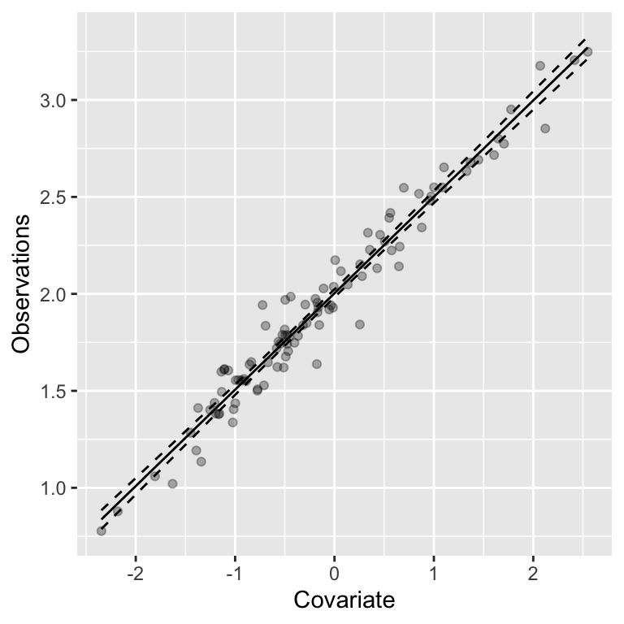

Data and 95% credible intervals

**R Code**

```r
pred %>% ggplot() +
  geom_point(aes(x,y), alpha = 0.3) +
  geom_line(aes(x,mean)) +
  geom_line(aes(x, q0.025), linetype = "dashed")+
  geom_line(aes(x, q0.975), linetype = "dashed")+
  xlab("Covariate") + ylab("Observations")
```

**Warning Task**

Generate predictions for the linear predictor $\mu$ when the covariate has value $x_0 = 0.45$.

What is the predicted value for $\mu$? And what is the uncertainty?

You can create a new data frame containing the new observation $x_0$ and then use the `predict` function.

```r
new_data = data.frame(x = 0.45)
pred = predict(fit.lm, new_data, ~ beta_0 + beta_1,
               n.samples = 1000)

pred
```

```
     x    mean         sd   q0.025     q0.5   q0.975   median sd.mc_std_err
1 0.45 2.22803 0.01137675 2.205508 2.227992 2.250356 2.227992  0.0002644507
  mean.mc_std_err
1    0.0003764898
```

You can see the predicted mean and sd by examining the produced `pred` object. In this case the mean is ca 2.22 with sd ca 0.01. This gives a 95% CI ca [2.20, 2.25].

**NOTE** Now we have produced a credible interval for the expected mean $\mu$ if we want to produce a *prediction* interval for a new observation $y$ we need to add the uncertainty that comes from the likelihood with precision $\tau_y$. To do this we can again use the `predict()` function to compute a 95% prediction interval for $y$.

```r
pred2 = predict(fit.lm, new_data,
               formula = ~ {
                 mu = beta_0 + beta_1
                 sigma = sqrt(1/Precision_for_the_Gaussian_observations)
                 list(q1 = qnorm(0.025, mean = mu, sd = sigma),
                      q2 =  qnorm(0.975, mean = mu, sd = sigma))},
               n.samples = 1000)
round(c(pred2$q1$mean, pred2$q2$mean),2)
```

```
[1] 2.03 2.43
```

Notice that now the interval we obtain is larger.